# Lesson 5 - 04/19/2015

### Multivariate Data

Notes:

```r
library(ggplot2)
pf <- read.csv("D:/EDA/R_wd/L3/pseudo_facebook.tsv", sep = '\t')
str(pf)
```

```
## 'data.frame':    99003 obs. of  15 variables:
##  $ userid               : int  2094382 1192601 2083884 1203168 1733186 1524765 1136133 1680361 1365174 1712567 ...
##  $ age                  : int  14 14 14 14 14 14 13 13 13 13 ...
##  $ dob_day              : int  19 2 16 25 4 1 14 4 1 2 ...
##  $ dob_year             : int  1999 1999 1999 1999 1999 1999 2000 2000 2000 2000 ...
##  $ dob_month            : int  11 11 11 12 12 12 1 1 1 2 ...
##  $ gender               : Factor w/ 2 levels "female","male": 2 1 2 1 2 2 2 1 2 2 ...
##  $ tenure               : int  266 6 13 93 82 15 12 0 81 171 ...
##  $ friend_count         : int  0 0 0 0 0 0 0 0 0 0 ...
##  $ friendships_initiated: int  0 0 0 0 0 0 0 0 0 0 ...
##  $ likes                : int  0 0 0 0 0 0 0 0 0 0 ...
##  $ likes_received       : int  0 0 0 0 0 0 0 0 0 0 ...
##  $ mobile_likes         : int  0 0 0 0 0 0 0 0 0 0 ...
##  $ mobile_likes_received: int  0 0 0 0 0 0 0 0 0 0 ...
##  $ www_likes            : int  0 0 0 0 0 0 0 0 0 0 ...
##  $ www_likes_received   : int  0 0 0 0 0 0 0 0 0 0 ...
```

### THIRD “QUALITATIVE” VARIABLE

Notes: - Adding mean to boxplot using stat_summary() - shape is used to change b/w point, triangle, cross etc

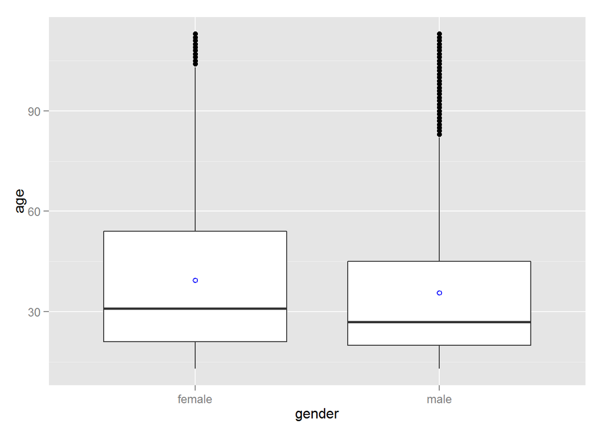

```r
ggplot(aes(x = gender, y = age),
       data = subset(pf, !is.na(gender))) +
  geom_boxplot() +
  stat_summary(geom = 'point', fun.y = "mean", color = 'blue', shape = 1)
```

### Plotting median by age and split by gender

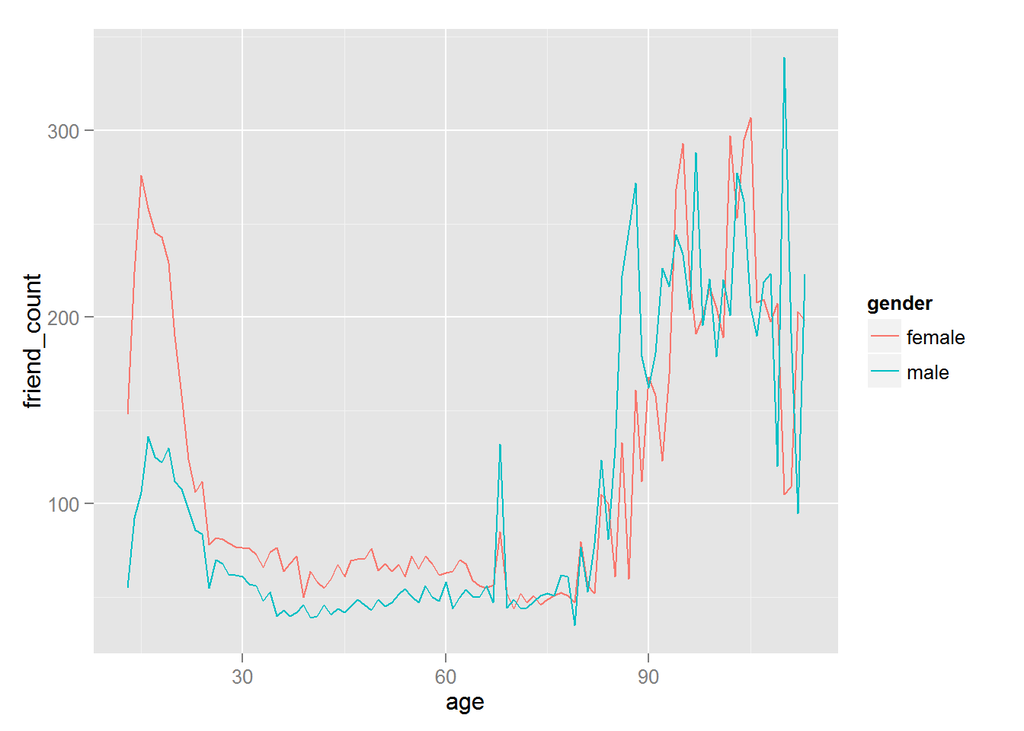

```r
# Note the fact that you need to put color wihtin aes for ggplot for this to work
ggplot(aes(x = age, y = friend_count),
       data = subset(pf, !is.na(gender))) +
  stat_summary(geom = 'line', fun.y = "median", aes(color = gender))
```

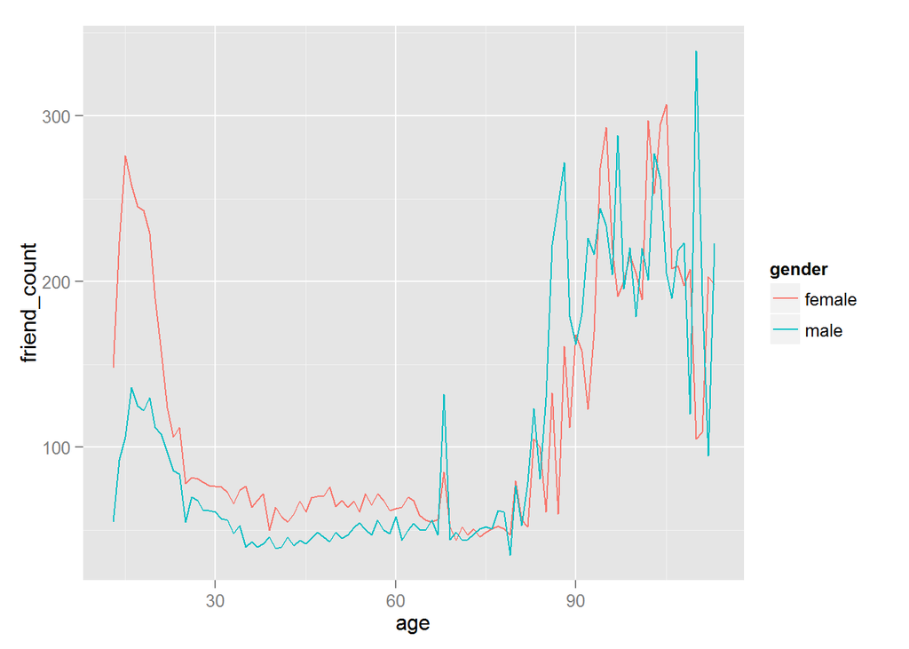

```r
# Another way of doing the same thing
ggplot(aes(x = age, y = friend_count),
       data = subset(pf, !is.na(gender))) +
  geom_line(stat = "summary", fun.y = "median", aes(color = gender))
```

### Plotting Conditional Summaries

Notes:

```r
# Another way of doing above manually using dplyr

# Write code to create a new data frame,
# called 'pf.fc_by_age_gender', that contains
# information on each age AND gender group.
# How the data frame should look like
#   age gender mean_friend_count median_friend_count    n
# 1  13 female          247.2953                 150  207
# 2  13   male          184.2342                  61  265
# 3  14 female          329.1938                 245  834
# 4  14   male          157.1204                  88 1201

library('dplyr')
pf.fc_by_age_gender <- subset(pf, !is.na(gender)) %>%
#pf.fc_by_age_gender <- pf %>%
#  filter(!is.na(gender))
  group_by(age, gender) %>%
  summarise(mean_friend_count = mean(as.numeric(friend_count)),
            median_friend_count = median(as.numeric(friend_count)),
            n = n()) %>%
  arrange(age, gender)

head(pf.fc_by_age_gender)
```

```
## Source: local data frame [6 x 5]
## Groups: age
##
##   age gender mean_friend_count median_friend_count    n
## 1  13 female          259.1606               148.0  193
## 2  13   male          102.1340                55.0  291
## 3  14 female          362.4286               224.0  847
## 4  14   male          164.1456                92.5 1078
## 5  15 female          538.6813               276.0 1139
## 6  15   male          200.6658               106.5 1478
```

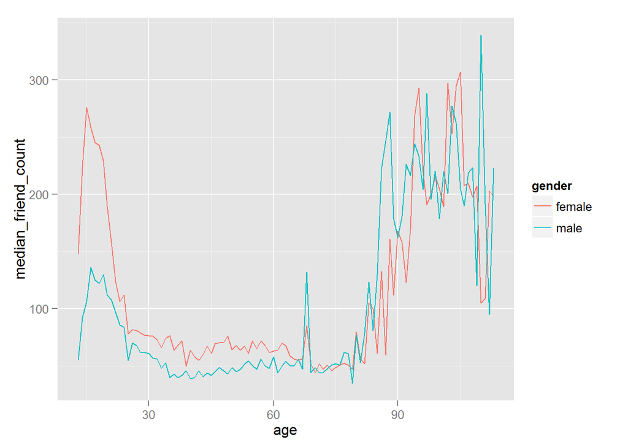

```r
qplot(data = pf.fc_by_age_gender, x = age, y = median_friend_count,
      color = gender, geom = 'line')
```

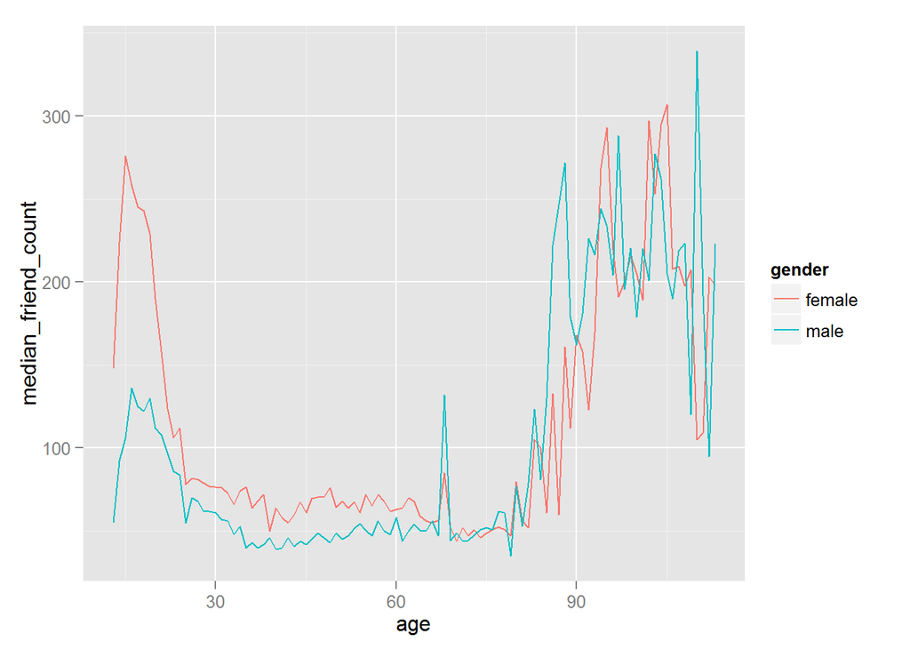

```r
# You could do the same using ggplot with geom_line() layer too
ggplot(data = pf.fc_by_age_gender, aes(x = age, y = median_friend_count)) +
      geom_line(aes(color = gender))
```

### Thinking in Ratios

Notes: - Note that females uniformly seem to have more friends than males - Ignore the part for age above 70 because that is noisy and we don’t have confidence in that range anyway - We want to look at the median ratios next to get a better sense of how much more than men

### Wide and Long Format

Notes: - Note that we have gender variable alternately as male and female (long format) - We could instead make this ‘wide format’ so that we have mean friend count for male and female separately - We can achieve this using tidyr but reshape2 looks easier

### Reshaping Data

Notes: - dcast() because we want output to be df. acast() for array - behind tilde will be what we want to maintain - after ~ will be what we want to reshape or widen and values to set is defined by value.var

```r
library(reshape2)
pf.fc_by_age_gender.wide <- dcast(data = pf.fc_by_age_gender,
                                  age ~ gender, value.var = "median_friend_count")
head(pf.fc_by_age_gender.wide)
```

```
##   age female  male
## 1  13  148.0  55.0
## 2  14  224.0  92.5
## 3  15  276.0 106.5
## 4  16  258.5 136.0
## 5  17  245.5 125.0
## 6  18  243.0 122.0
```

#### Response:

We can go back from wide to long using melt(). Haven’t explored that though

### Ratio Plot

Notes: Plot ratio of median female to median male friend_count

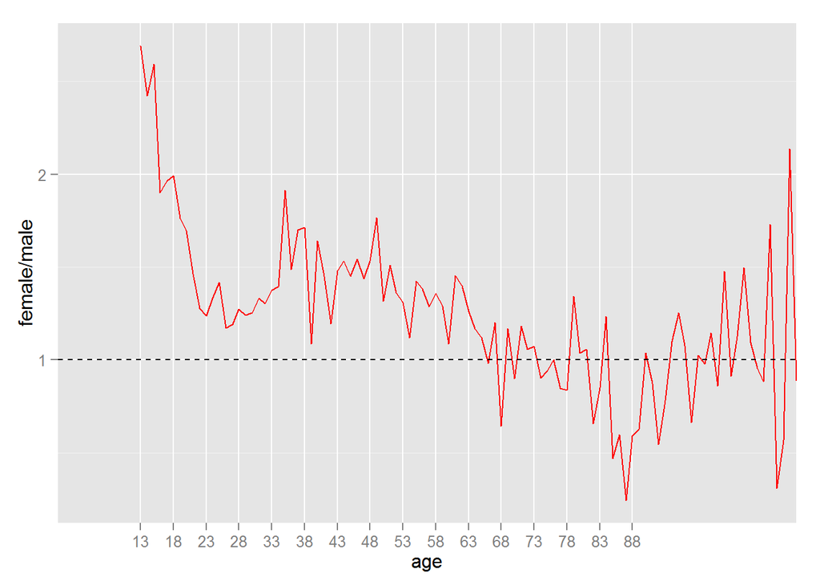

```r
ggplot(data = pf.fc_by_age_gender.wide, aes(x = age, y = female/male)) +
  geom_line(color = 'red') +
  geom_hline(linetype = 2, yintercept = 1) +
  scale_x_discrete(breaks = seq(13, 90, 5))
```

#### Response:

In the 13 to 18 age group, women have 2 to 2.5x more friends. But even otherwise, this plot shows that women consistently have more friends than men for age <= 70

## THIRD “QUANTITATIVE” VARIABLE

Notes: - It is likely that the more time you have been on facebook, you have accumulated more friends. - To explore this, create year_joined using tenure variable and current year as 2014

```r
pf$year_joined = with(pf, floor(2014 - tenure/365))
head(pf)
```

```
##    userid age dob_day dob_year dob_month gender tenure friend_count
## 1 2094382  14      19     1999        11   male    266            0
## 2 1192601  14       2     1999        11 female      6            0
## 3 2083884  14      16     1999        11   male     13            0
## 4 1203168  14      25     1999        12 female     93            0
## 5 1733186  14       4     1999        12   male     82            0
## 6 1524765  14       1     1999        12   male     15            0
##   friendships_initiated likes likes_received mobile_likes
## 1                     0     0              0            0
## 2                     0     0              0            0
## 3                     0     0              0            0
## 4                     0     0              0            0
## 5                     0     0              0            0
## 6                     0     0              0            0
##   mobile_likes_received www_likes www_likes_received year_joined
## 1                     0         0                  0        2013
## 2                     0         0                  0        2013
## 3                     0         0                  0        2013
## 4                     0         0                  0        2013
## 5                     0         0                  0        2013
## 6                     0         0                  0        2013
```

```r
table(pf$year_joined)
```

```
##
##  2005  2006  2007  2008  2009  2010  2011  2012  2013  2014
##     9    15   581  1507  4557  5448  9860 33366 43588    70
```

### Cut a Variable

Notes: - Since we don’t have too many users in some years, we want to bucketize in 4 categories - Add variable year_joined.bucket using cut() - ‘()’ means exclude and ‘[]’ means include # (2004, 2009] # (2009, 2011] # (2011, 2012] # (2012, 2014]

```r
pf$year_joined.bucket <- with(pf, cut(year_joined, include.lowest = F, breaks = c(2004, 2009, 2011, 2012, 2014)))
table(pf$year_joined.bucket)
```

```
##
## (2004,2009] (2009,2011] (2011,2012] (2012,2014]
##        6669       15308       33366       43658
```

### Plotting it All Together

Notes: Line plot using year_joined.bucket

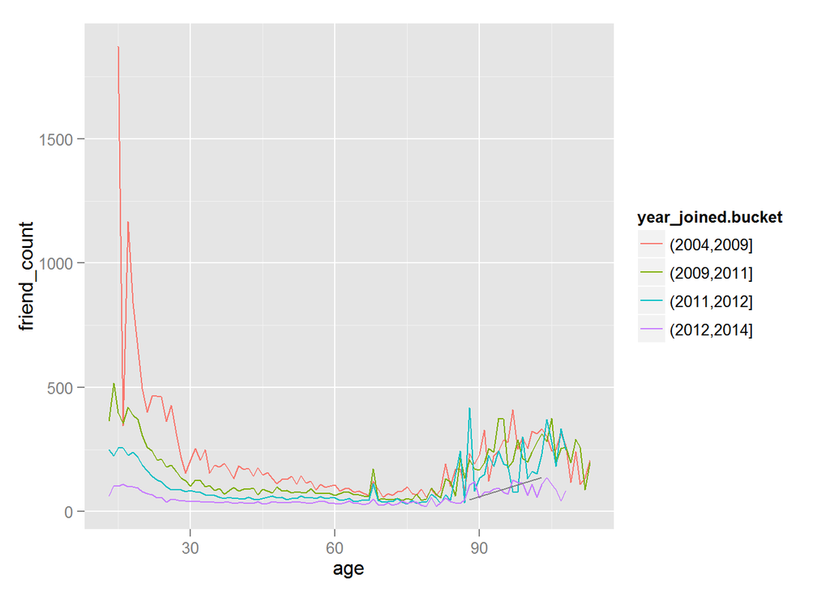

```r
ggplot(aes(x = age, y = friend_count),
       data = subset(pf, !is.na(age))) +
  geom_line(stat = "summary", fun.y = "median", aes(color = year_joined.bucket))
```

#### Response:

As suspected, we see that people who have stayed longer on FB have more friends ***

### Plot the Grand Mean

Notes: Line plot using means instead and add a grand mean with a different linetype

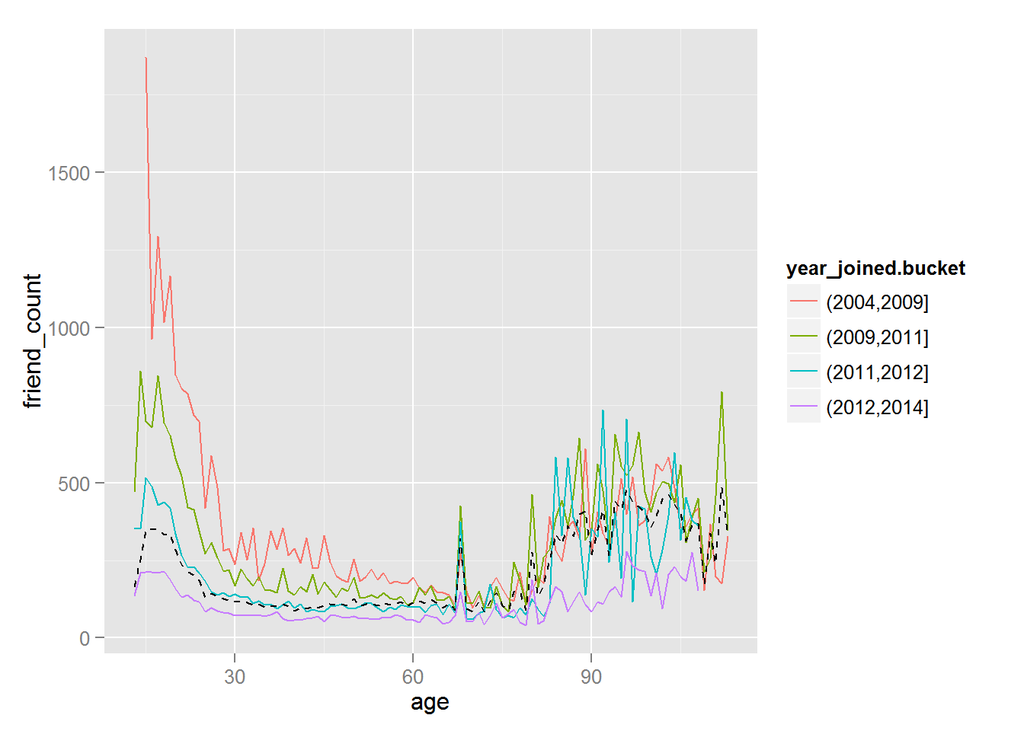

```r
ggplot(aes(x = age, y = friend_count),
       data = subset(pf, !is.na(year_joined.bucket))) +
  geom_line(stat = "summary", fun.y = "mean", aes(color = year_joined.bucket)) +
  geom_line(stat = "summary", fun.y = "mean", linetype = 2)              # grand mean
```

#### Response:

Grand mean plot basically tells us that much of the data is for the newer cohorts due to its proximity to the 2011-2012 cohort *** ### Friending Rate Notes: Friends per day of tenure

```r
with(subset(pf, tenure > 0), summary(friend_count/tenure))
```

```
##     Min.  1st Qu.   Median     Mean  3rd Qu.     Max.
##   0.0000   0.0775   0.2205   0.6096   0.5658 417.0000
```

### Friendships Initiated

What is the median friend rate? 0.22

What is the maximum friend rate? 417

NOte: Create a line graph of mean of friendships_initiated per day (of tenure) vs. tenure colored by year_joined.bucket.

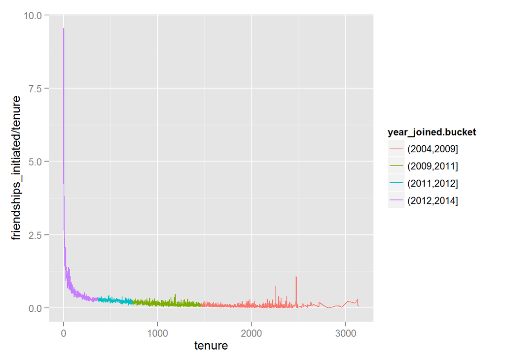

```r
ggplot(data = subset(pf, tenure >0), aes(x = tenure, y = friendships_initiated/tenure)) +
  geom_line(stat = "summary", fun.y = mean, aes(color = year_joined.bucket))
```

Notes: This shows that people go a friending frenzy when they join and rate goes down with tenure as hypothesized

### Bias-Variance Tradeoff Revisited

Notes:

```r
library('gridExtra')
```

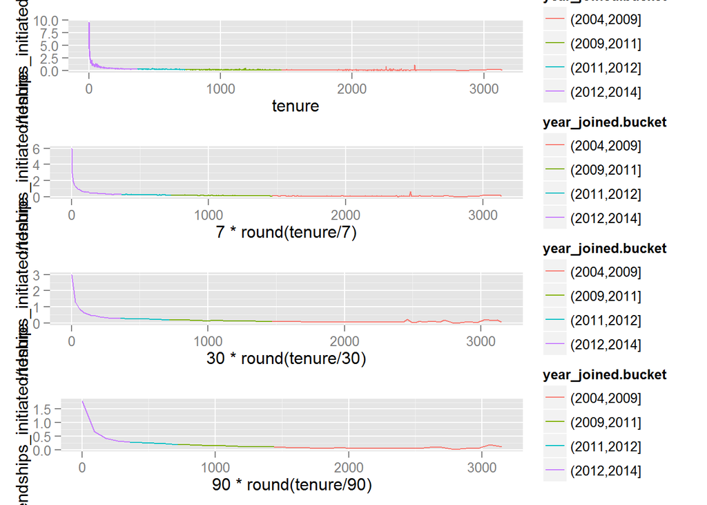

```r
p1 <- ggplot(aes(x = tenure, y = friendships_initiated / tenure),
       data = subset(pf, tenure >= 1)) +
  geom_line(aes(color = year_joined.bucket),
            stat = 'summary',
            fun.y = mean)

p2 <- ggplot(aes(x = 7 * round(tenure / 7), y = friendships_initiated / tenure),
       data = subset(pf, tenure > 0)) +
  geom_line(aes(color = year_joined.bucket),
            stat = "summary",
            fun.y = mean)

p3 <- ggplot(aes(x = 30 * round(tenure / 30), y = friendships_initiated / tenure),
       data = subset(pf, tenure > 0)) +
  geom_line(aes(color = year_joined.bucket),
            stat = "summary",
            fun.y = mean)

# Notice how the slope reduced quite a bit in this version from original (over-smoothing)
p4 <- ggplot(aes(x = 90 * round(tenure / 90), y = friendships_initiated / tenure),
       data = subset(pf, tenure > 0)) +
  geom_line(aes(color = year_joined.bucket),
            stat = "summary",
            fun.y = mean)

grid.arrange(p1, p2, p3, p4, ncol = 1)
```

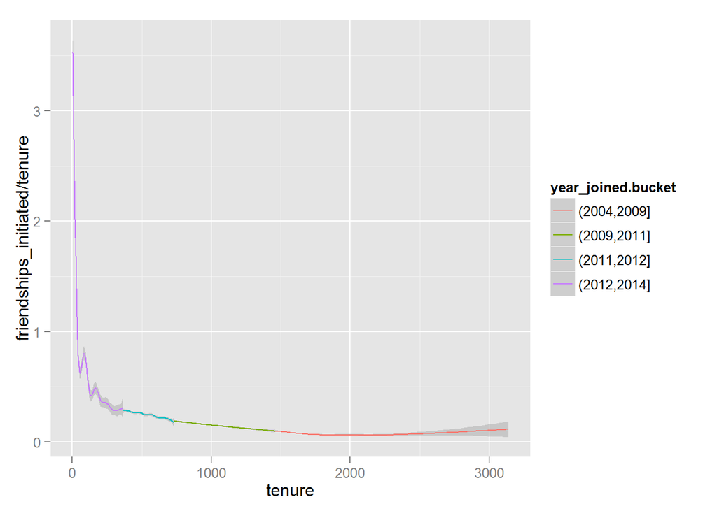

```r
ggplot(data = subset(pf, tenure >0), aes(x = tenure, y = friendships_initiated/tenure)) +
  geom_smooth(aes(color = year_joined.bucket))
```

#### Response:

Smoothing shows the less noisier version that we tried to do with rounding

### Proportions of friendships initiated

```r
pf$prop_initiated <- with(pf, friendships_initiated/friend_count)
str(pf)
```

```
## 'data.frame':    99003 obs. of  18 variables:
##  $ userid               : int  2094382 1192601 2083884 1203168 1733186 1524765 1136133 1680361 1365174 1712567 ...
##  $ age                  : int  14 14 14 14 14 14 13 13 13 13 ...
##  $ dob_day              : int  19 2 16 25 4 1 14 4 1 2 ...
##  $ dob_year             : int  1999 1999 1999 1999 1999 1999 2000 2000 2000 2000 ...
##  $ dob_month            : int  11 11 11 12 12 12 1 1 1 2 ...
##  $ gender               : Factor w/ 2 levels "female","male": 2 1 2 1 2 2 2 1 2 2 ...
##  $ tenure               : int  266 6 13 93 82 15 12 0 81 171 ...
##  $ friend_count         : int  0 0 0 0 0 0 0 0 0 0 ...
##  $ friendships_initiated: int  0 0 0 0 0 0 0 0 0 0 ...
##  $ likes                : int  0 0 0 0 0 0 0 0 0 0 ...
##  $ likes_received       : int  0 0 0 0 0 0 0 0 0 0 ...
##  $ mobile_likes         : int  0 0 0 0 0 0 0 0 0 0 ...
##  $ mobile_likes_received: int  0 0 0 0 0 0 0 0 0 0 ...
##  $ www_likes            : int  0 0 0 0 0 0 0 0 0 0 ...
##  $ www_likes_received   : int  0 0 0 0 0 0 0 0 0 0 ...
##  $ year_joined          : num  2013 2013 2013 2013 2013 ...
##  $ year_joined.bucket   : Factor w/ 4 levels "(2004,2009]",..: 4 4 4 4 4 4 4 4 4 4 ...
##  $ prop_initiated       : num  NaN NaN NaN NaN NaN NaN NaN NaN NaN NaN ...
```

### Friendships initiated proportion vs. tenure colored by year_joined.bucket in line plot

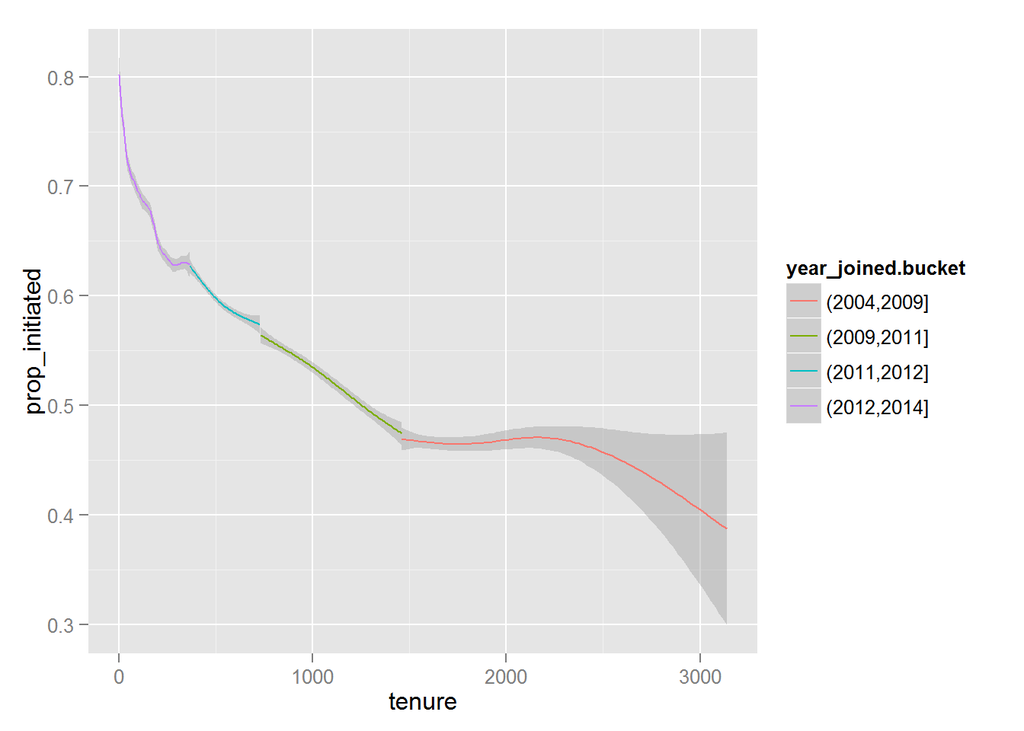

```r
# Some bug here is throwing up an error, but I can't figure it out
#ggplot(data = subset(pf, !is.nan(prop_initiated)), aes(x = tenure, y = prop_initiated)) +
#  geom_line(stat = "summary", fun.y = "mean", aes(color = year_joined.bucket))

ggplot(data = pf, aes(x = tenure, y = prop_initiated)) +
  geom_smooth(aes(color = year_joined.bucket))
```

Response: We see that users who joined after 2012 initiated the greatest proportion of friendships

### Sean’s NFL Fan Sentiment Study

Notes: https://www.facebook.com/notes/facebook-data-science/the-emotional-highs-and-lows-of-the-nfl-season/10152033221418859 Bias vs Variance tradeoff Plotting postive words/negative words ratio captured from facebook during NFL season and tagging data by team-fan Best plot emerges when using 7 day MA which captures the peaking and lowing on game day - Smoothing functions are also called ‘splines’

### Introducing the Yogurt Data Set

Notes: Using scanner data to gauge customer sentiment. Bayesian shrinkage used in the real world retail models https://hbr.org/2000/03/making-sense-of-scanner-data/ar/1

### Histograms Revisited

Notes: Load in yogurt data set and convert id variable to a factor

```r
yo <- read.csv("D:/EDA/R_wd/L5/yogurt.csv")
str(yo)
```

```
## 'data.frame':    2380 obs. of  9 variables:
##  $ obs        : int  1 2 3 4 5 6 7 8 9 10 ...
##  $ id         : int  2100081 2100081 2100081 2100081 2100081 2100081 2100081 2100081 2100081 2100081 ...
##  $ time       : int  9678 9697 9825 9999 10015 10029 10036 10042 10083 10091 ...
##  $ strawberry : int  0 0 0 0 1 1 0 0 0 0 ...
##  $ blueberry  : int  0 0 0 0 0 0 0 0 0 0 ...
##  $ pina.colada: int  0 0 0 0 1 2 0 0 0 0 ...
##  $ plain      : int  0 0 0 0 0 0 0 0 0 0 ...
##  $ mixed.berry: int  1 1 1 1 1 1 1 1 1 1 ...
##  $ price      : num  59 59 65 65 49 ...
```

```r
yo$id <- factor(yo$id)
str(yo)
```

```
## 'data.frame':    2380 obs. of  9 variables:
##  $ obs        : int  1 2 3 4 5 6 7 8 9 10 ...
##  $ id         : Factor w/ 332 levels "2100081","2100370",..: 1 1 1 1 1 1 1 1 1 1 ...
##  $ time       : int  9678 9697 9825 9999 10015 10029 10036 10042 10083 10091 ...
##  $ strawberry : int  0 0 0 0 1 1 0 0 0 0 ...
##  $ blueberry  : int  0 0 0 0 0 0 0 0 0 0 ...
##  $ pina.colada: int  0 0 0 0 1 2 0 0 0 0 ...
##  $ plain      : int  0 0 0 0 0 0 0 0 0 0 ...
##  $ mixed.berry: int  1 1 1 1 1 1 1 1 1 1 ...
##  $ price      : num  59 59 65 65 49 ...
```

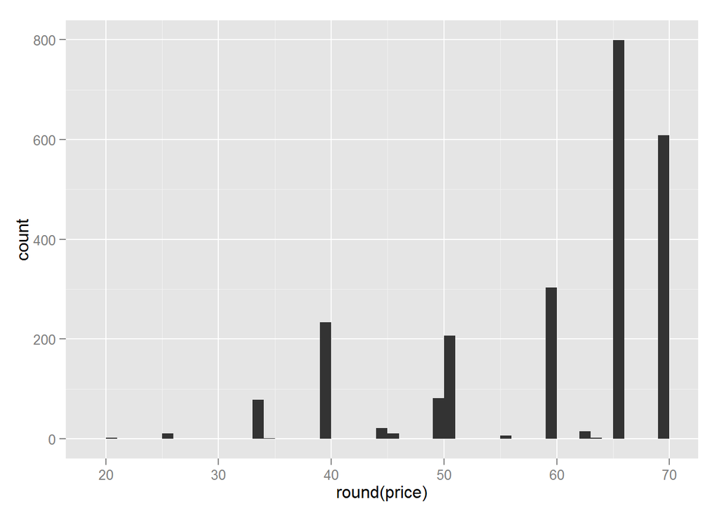

```r
qplot(data = yo, x = round(price), binwidth = 1)
```

### Number of Purchases

Notes: We can look at number of unique price points in data using unique and table

```r
table(yo$price)
```

```
##
##    20 24.96 33.04  33.2 33.28 33.36 33.52 39.04    44 45.04 48.96 49.52
##     2    11    54     1     1    22     1   234    21    11    81     1
##  49.6    50 55.04 58.96    62 63.04 65.04 68.96
##     1   205     6   303    15     2   799   609
```

```r
yo_price.unique <- sort(unique(yo$price))
yo_price.unique
```

```
##  [1] 20.00 24.96 33.04 33.20 33.28 33.36 33.52 39.04 44.00 45.04 48.96
## [12] 49.52 49.60 50.00 55.04 58.96 62.00 63.04 65.04 68.96
```

```r
yo$all.purchases <- with(yo, strawberry + blueberry + pina.colada + plain + mixed.berry)
head(yo)
```

```
##   obs      id  time strawberry blueberry pina.colada plain mixed.berry
## 1   1 2100081  9678          0         0           0     0           1
## 2   2 2100081  9697          0         0           0     0           1
## 3   3 2100081  9825          0         0           0     0           1
## 4   4 2100081  9999          0         0           0     0           1
## 5   5 2100081 10015          1         0           1     0           1
## 6   6 2100081 10029          1         0           2     0           1
##   price all.purchases
## 1 58.96             1
## 2 58.96             1
## 3 65.04             1
## 4 65.04             1
## 5 48.96             3
## 6 65.04             4
```

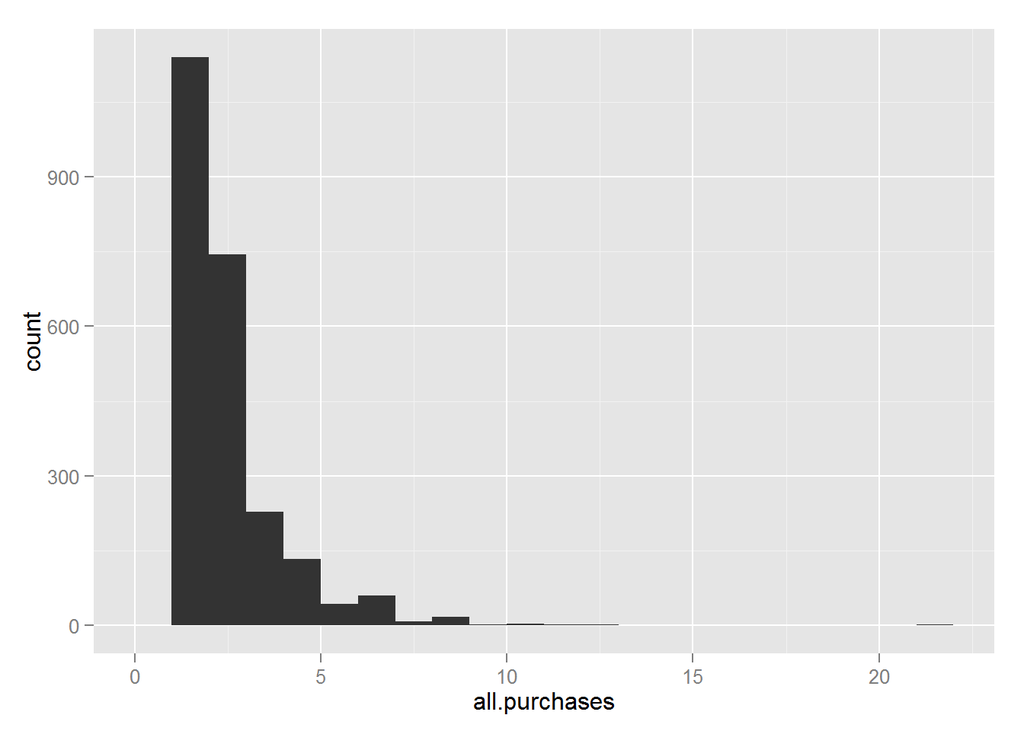

```r
# Histogram of #purchases per scan
qplot(data = yo, x = all.purchases, binwidth = 1)
```

#### Response:

Most people buy just one or two yogurts at a time

### Prices over Time

Notes: This kind of plotting is time series data

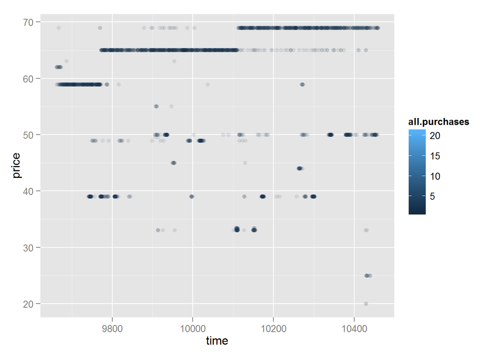

```r
ggplot(data = yo, aes(x = time, y = price)) +
  geom_point(alpha = 1/10, aes(color = all.purchases))
```

### Sampling Observations

Notes: - Since there are a lot of observations, it may be instructive to pick a random sample and look at that in more detail - We have multiple samples per household(id), so we really want to sample by household so that we track a household’s buying habits over time

### Looking at Samples of Households

```r
set.seed(4980)
sample.ids <- sample(x = levels(yo$id), size = 16, replace = F)
sample.ids
```

```
##  [1] "2140483" "2110031" "2105346" "2126102" "2135996" "2147892" "2105155"
##  [8] "2144048" "2113779" "2115998" "2169268" "2133272" "2133207" "2121533"
## [15] "2152264" "2112516"
```

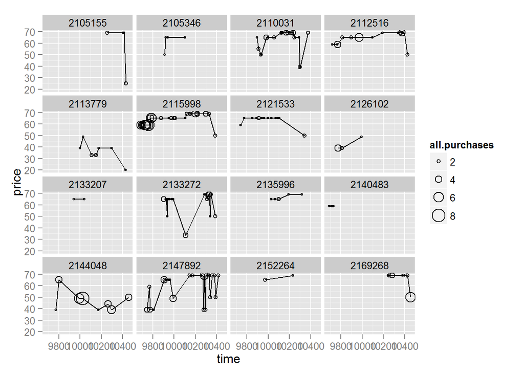

```r
# x %in% y returns a logical (boolean) vector the same length as x that says whether each entry in x appears in y.
ggplot(data = subset(yo, id %in% sample.ids), aes(x = time, y = price)) +
  facet_wrap( ~ id) +
  geom_line() +
  geom_point(aes(size = all.purchases), pch = 1)    #pch is just for setting point type
```

Notes: In a couple of households, I saw purchases going up when price was lower (discount or coupons?), but overall, no significant price sensitivity to #purchase noticed ***

### The Limits of Cross Sectional Data

Notes: FB dataset not great to do time series analysis because we only have one snapshot captured, not multiple snapshots over time.

### Many Variables

Notes: - EDA may be a key toolset for feature engineering which machine learning experts say is one of the most challenging part of predictive analysis - Often, in the real world, there are going to be hundreds of features in the dataset - We want to predict an output variable as a function of these input variables - Some features may be obvious (intuition and domain knowledge), but for some which we may have overlooked, EDA gives a way to identify important features - Scatterplots and heat-maps may be some techniques to speed up the feature engineering process.

### Scatterplot Matrix

Notes: Find the generated scatter plot matrix here https://s3.amazonaws.com/udacity-hosted-downloads/ud651/scatterplotMatrix.pdf

### Heat Maps

Notes: - http://www.r-bloggers.com/melt/ - Below data set is genomic data - Analysis of which gene expresses which set of cases

```r
nci <- read.table("nci.tsv")
colnames(nci) <- c(1:64)    # just transform feature names to numbers
```

### Heat map code is actually quite simple to understand

```r
# samples only first 200 observations from dataset
# Convert from wide form to long form aka opposite of dcast()
nci.long.samp <- melt(as.matrix(nci[1:200,]))
names(nci.long.samp) <- c("gene", "case", "value")
head(nci.long.samp)
```

```
##   gene case  value
## 1    1    1  0.300
## 2    2    1  1.180
## 3    3    1  0.550
## 4    4    1  1.140
## 5    5    1 -0.265
## 6    6    1 -0.070
```

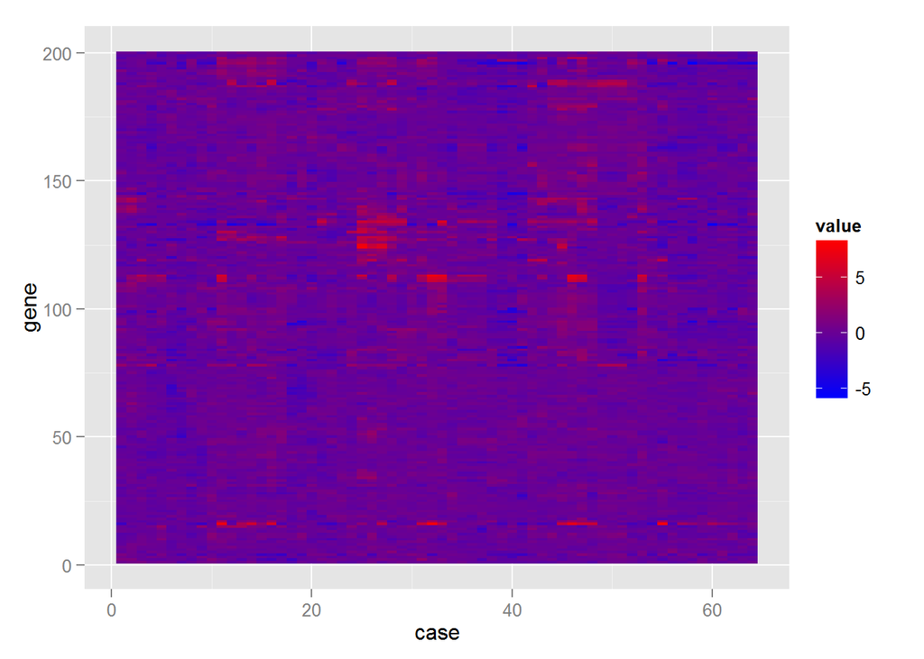

```r
ggplot(aes(y = gene, x = case, fill = value),
  data = nci.long.samp) +
  geom_tile() +
  scale_fill_gradientn(colours = colorRampPalette(c("blue", "red"))(100))
```

### Analyzing Three of More Variables

Reflection: - We looked adding a third qualitative (gender) and quantitative variable (tenure) to age vs. friend_count analysis - We used mean and median summaries (conditional summaries) to reduce the noise in these plots - This was achieved by using dplyr to create new summary dataframes or more easily by just using geom_line with fun.y method  
- We used cut() for bucketing year_joined variable - We used dcast() from reshape2 to transform from long form to wide form for analysis of friend_count by gender - We saw the bias vs. variance trade-off again. geom_smooth() helps you smooth noise automatically (aka splines) - We also saw in the NFL sentiment that figuring out the amount of smoothing is critical to getting the correct information - For yogurt dataset we created a time series plot of price vs. time with scatterplots - Since yogurt dataset had multiple observations per household(id), we sampled households randomly using sample() based on a seed and then explored the size of purchase over time faceted by household (id) - Finally, we took a brief look at scatter plot matrices (fb data) and heat maps (for genomic data)